# Who are Jordan Peterson’s followers?

The new ideological fractures

Last updated on Oct 7, 2019 5 min read theory & empirics

I’ve been curious about the new massive camp of Jordan Peterson acolytes. In one of my many prodigal late-night lurking sessions through the depths of Reddit, I noticed they collected some data on themselves. So here we go.

If you’ve been following my recent [writing](http://jmrphy.net/blog/), [podcasts](http://jmrphy.libsyn.com/), and [videos](https://www.youtube.com/justinmurphy), you’ll know I’m especially interested in the relationships between [education](http://jmrphy.net/blog/2016/11/10/if-educated-progressives-are-so-smart-why-is-right-wing-populism-succeeding/), [political correctness](http://jmrphy.net/blog/2017/05/15/psychology-of-prohibiting-outside-thinkers/), [taboo topics](http://jmrphy.libsyn.com/other-life-6-diana-s-fleischman), and [ideology](https://youtu.be/ZVKyghPoYa0).

I’ve been hypothesizing that there is a substantial number of culturally conservative (against [the cultural leftism of the West](http://jmrphy.net/blog/2017/09/04/americans-conservative-liberal-left-right/)) but libertarian (let people do what they want, free speech, etc.) folks, who have been increasingly shut out from mainstream Western political culture for decades now. Not just from the left, but from a mainstream right that bows before cultural leftism (what the right internet lovingly refers to as “cucks”).

In many educated circles, support for Donald Trump is seen as somewhere between insane and evil, quite seriously. Yet, about 50% of the Americans who voted did so for him, so we know at least a non-trivial number of educated people voted for him. But who are they? I haven’t really had strong intuitions about this, and my sense is you just don’t really see or hear from educated and highly thoughtful Trump supporters. I’m aware this could definitely be “my bubble,” but I don’t think it’s just that. I think there exist thoughtful educated Trump supporters, but I think they are systematically unlikely to appear in mainstream culture.

But I have been watching closely the explosion of popularity enjoyed by academic psychologist Jordan Peterson, and it has seemed to me that his constituency might just be some of the educated Trumpians. It is also consistent with my “long-term mass suppression” thesis, because this helps to explain how a [random academic psychologist](http://amzn.to/2ES8FAX) achieved genuinely extraordinary, [anomolous levels of fame](http://amzn.to/2GvQ4rR) all of a sudden. It’s the same pattern with Trump (though I’m not, at all, equating the two individuals): a massive unexpected and rise-to-power indicating a massive reservoir of public interest in something that has hitherto been systematically under-supplied by the status quo.

So with these ideas in mind, let’s take a look at support for Trump, education levels, and identifications in the “four quadrant” model of ideology.

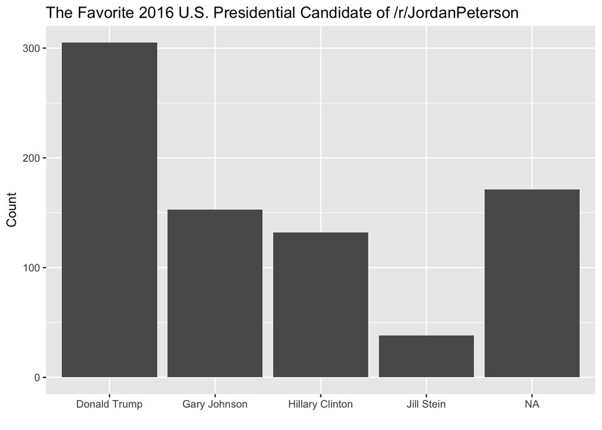

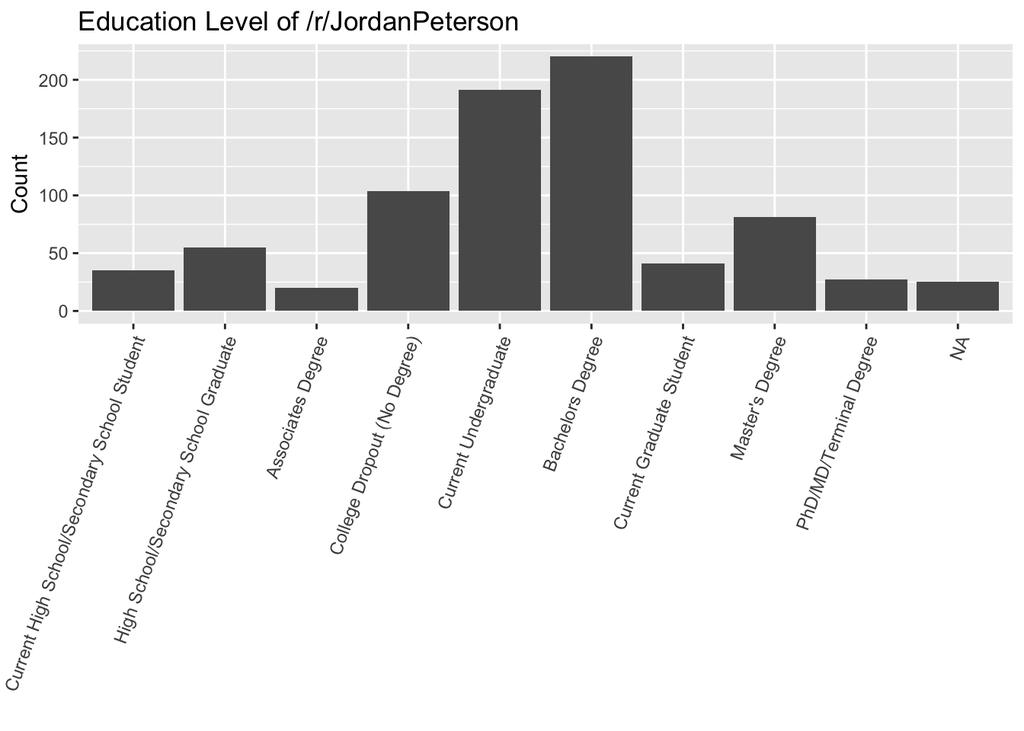

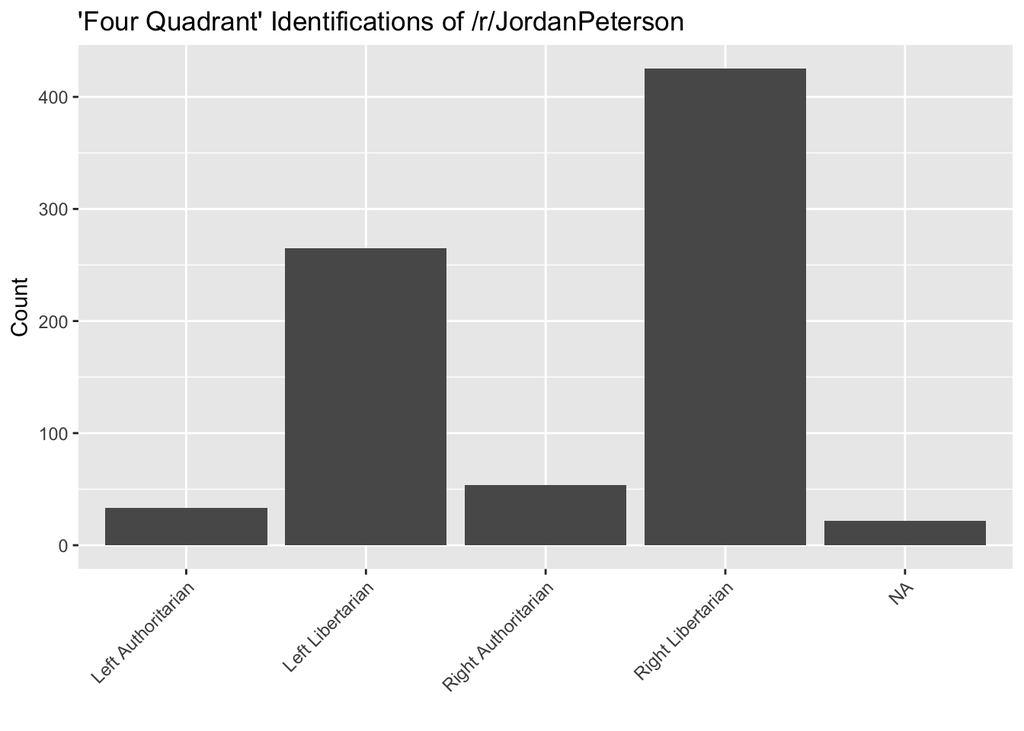

### Correlation plot

Let’s look into the structure of the more specific beliefs in the survey.

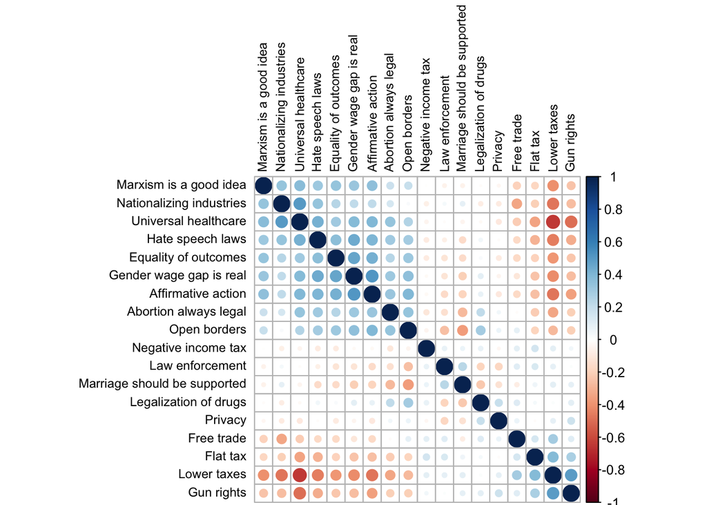

### How many factors?

The following graph shows how every additional factor explains less and less of the variance. Rule of thumb is that the optimal number of factors is the “elbow” in the graph. The different colors in the legend represent the different ways of calculating the optimal factor solution. Two of them suggest 3, and that’s the elbow, so we’ll go with 3 factors.

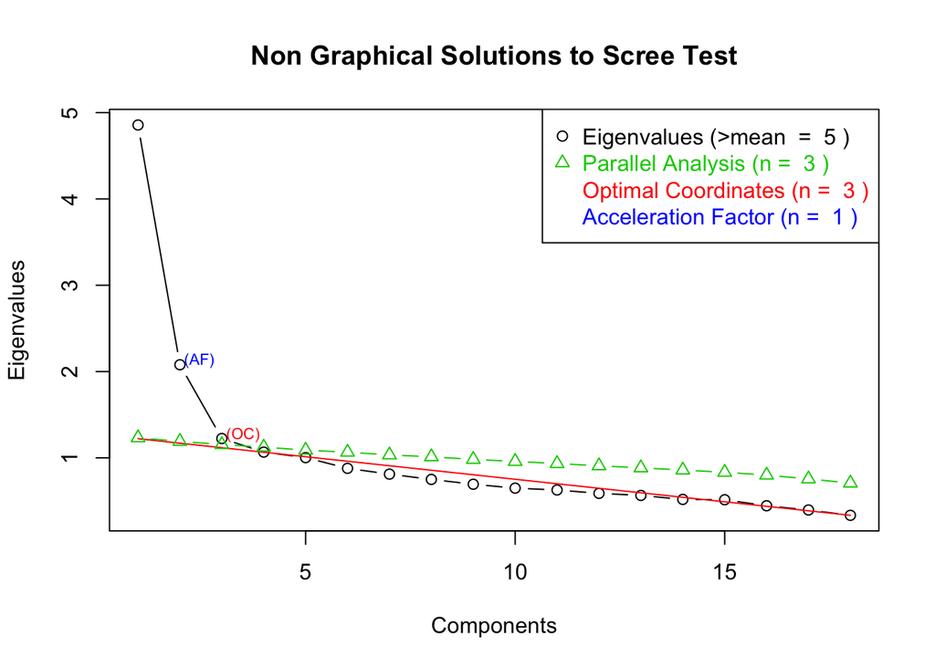

```
##
## Loadings:
##                              Factor1 Factor2 Factor3
## Lower taxes                  -0.790   0.181
## Nationalizing industries      0.513  -0.384
## Marxism is a good idea        0.512           0.133
## Universal healthcare          0.748  -0.245  -0.200
## Flat tax                     -0.437           0.106
## Equality of outcomes          0.554   0.149   0.315
## Negative income tax          -0.104
## Free trade                   -0.276   0.287  -0.122
## Abortion always legal         0.467   0.259  -0.180
## Gun rights                   -0.552   0.155
## Hate speech laws              0.614
## Law enforcement              -0.149  -0.320
## Legalization of drugs                 0.445  -0.196
## Gender wage gap is real       0.627   0.225   0.261
## Marriage should be supported -0.213  -0.492   0.133
## Open borders                  0.461   0.519  -0.109
## Privacy                               0.228  -0.195
## Affirmative action            0.653   0.192   0.199
##
##                Factor1 Factor2 Factor3
## SS loadings       4.31   1.395   0.458
## Proportion Var    0.24   0.078   0.025
## Cumulative Var    0.24   0.317   0.342
```

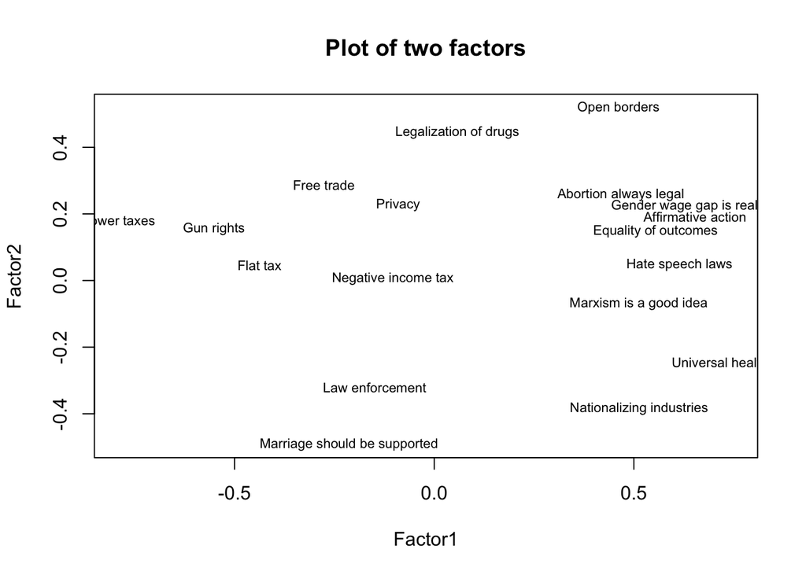

This structure is pretty standard in political science. Factor 1 is economic conservatism vs. economic liberalism (leftism), Factor 2 is social conservatism vs. social liberalism.

### What I find interesting here

Lo and behold, the data from /r/JordanPeterson seem broadly consistent with the hypothesis I sketched at the beginning.

As an ultralefty who is also 90% on board with Peterson’s key messages, I honestly did not expect this many of the Peterson disciples to be Trump supporters. I was thinking I’d find a sizable minority and say “Aha! A little evidence for my hypothesis.” But Trump is far and away the most favored candidate.

The reason this is important, in my view, is that Trump and Trump supporters are genuinely seen as unworthy of intellectually serious debate in progressive educated circles. But Peterson is an undeniable intellectual master of the most authentic kind. What this means is that genuinely educated progressives who are opposed to Trump need (if they are serious and sincere) to go through Peterson and his intellectual community. In other words, educated progressives cannot pretend there are no serious intellectual forces associated with Trump. There is at least one, and it’s the cluster of ideas Peterson has been working on for decades. To be clear, I am not saying Peterson has *caused* support for Trump and I’m not saying Peterson himself supports Trump (I don’t know, but he generally avoids naïve blanket identifications.) I am just saying that, as far as I can tell, his perspective represents a major, public intellectual force that coincides with at least some vectors of support for Trump.

And the sizable minority of left libertarians makes sense to me (because that’s me, basically). So it’s interesting that left-libertarians are communicating thoughtfully in a community with many Trump supporters. I want to show this to all the left libertarian activists I know (who are very different than left libertarian people in general). To show them there is serious intellectual content in the new seeming “right-wing” ecology of ideas and figures, which they see as one big “alt-right” to be stopped by “no platforming” everything. But I probably won’t bother, because radical left activist types are generally not in the business of learning.

This was just a short exploration. If you have any questions or additional analyses you would be super interested to see, leave a comment.

data visualization ideology social science

### Related

- Are Americans becoming more conservative or liberal (right or left)?
- Graph of economic growth and democracy across countries over time
- Slides on 'Democracy' as propaganda for capitalism
- Generating summary statistics and box/violin plots in R
- A quick-start guide to the statistical analysis of political attitudes and behaviors

[comments powered by Disqus](https://disqus.com)